# HW7 - ARIMA

Hung Jui Chao

2026-11-17

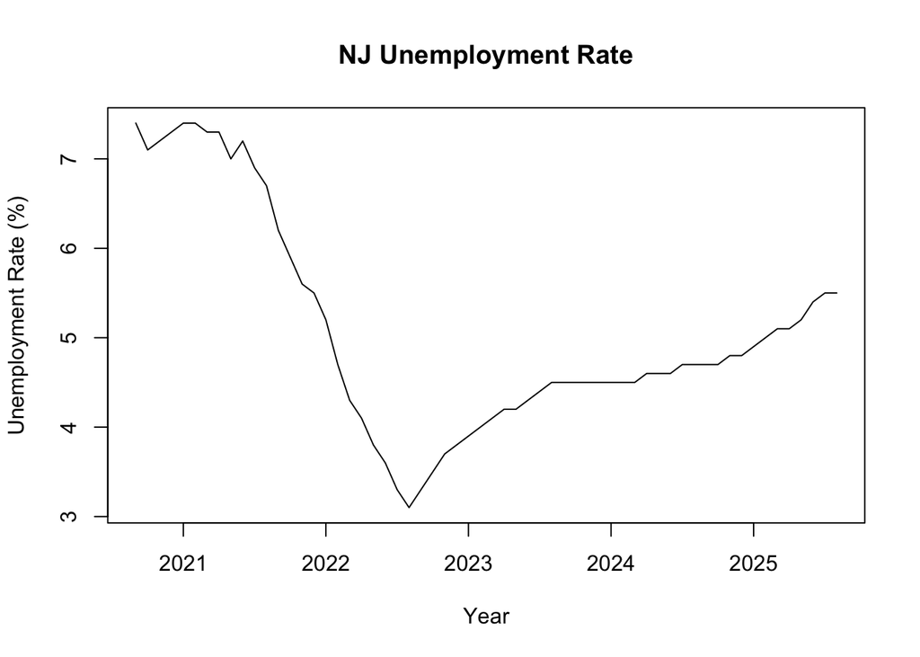

```r
library(forecast)
library(readxl)

NJ = read_excel("NJ_Unemployment_Rate_5Y.xlsx")

NJ_ts <- ts(NJ$NJ_Unemployment_Rate,
            start = c(2020, 9),
            frequency = 12)

plot(NJ_ts,
     main = "NJ Unemployment Rate",
     xlab = "Year",
     ylab = "Unemployment Rate (%)")
```

# Check for differencing for ARIMA

```r
ndiffs(NJ_ts)
```

```
## [1] 2
```

# Based on the results, the NJ unemployment rate time series requires second-order differencing (d = 2) to achieve stationarity.

# Check ACF and PACF to decide p & q for each times of differencing

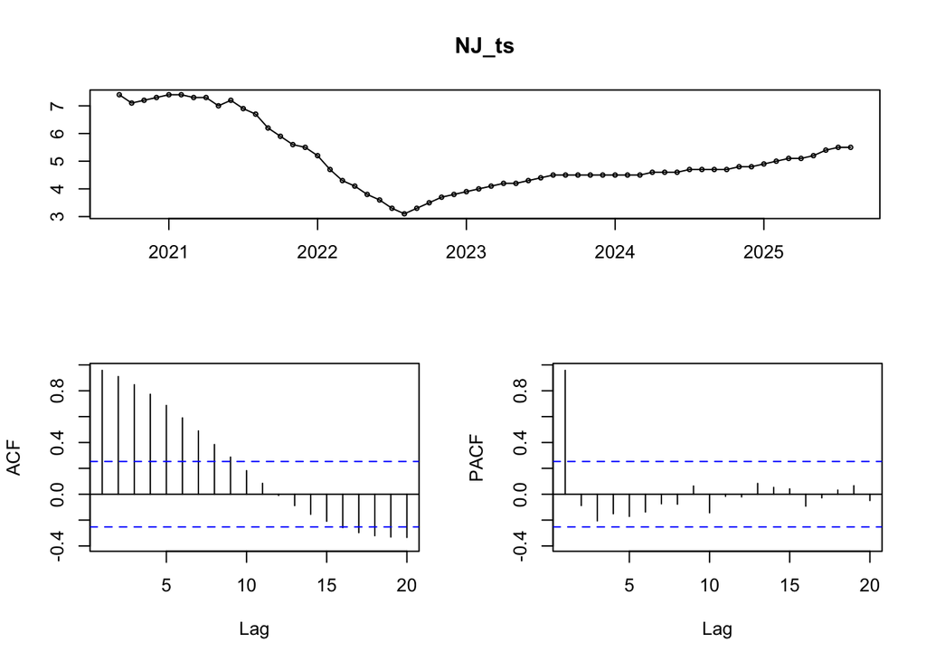

```r
# Zero Differencing
tsdisplay(NJ_ts)
```

# The zero differencing series shows a clear trend, and the ACF decreases slowly, indicating non-stationarity. The PACF has a significant spike at Lag 1, suggesting p might be 0 or 1, while q is unclear. Differencing is needed before selecting p and q.

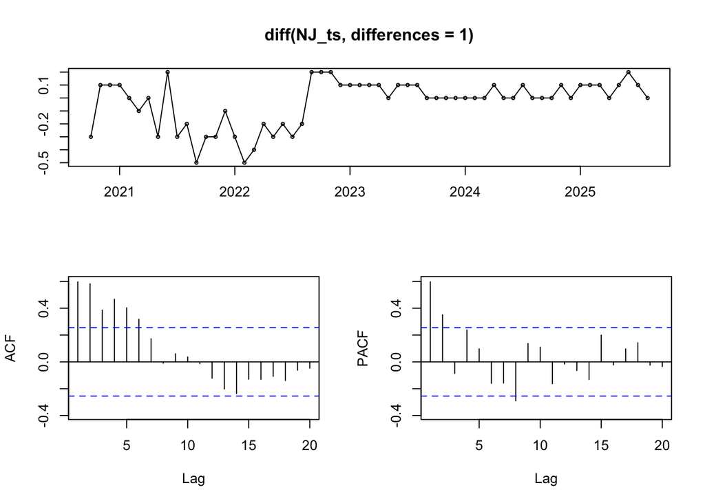

```r
# One time differencing
tsdisplay(diff(NJ_ts, differences = 1))
```

# After first differencing, the ACF still decreases gradually, suggesting possible non-stationarity. The PACF shows significant spikes at Lags 1 and 2, suggesting p might be 0, 1, or 2. Since the ACF does not show a clear cutoff, q remains uncertain.

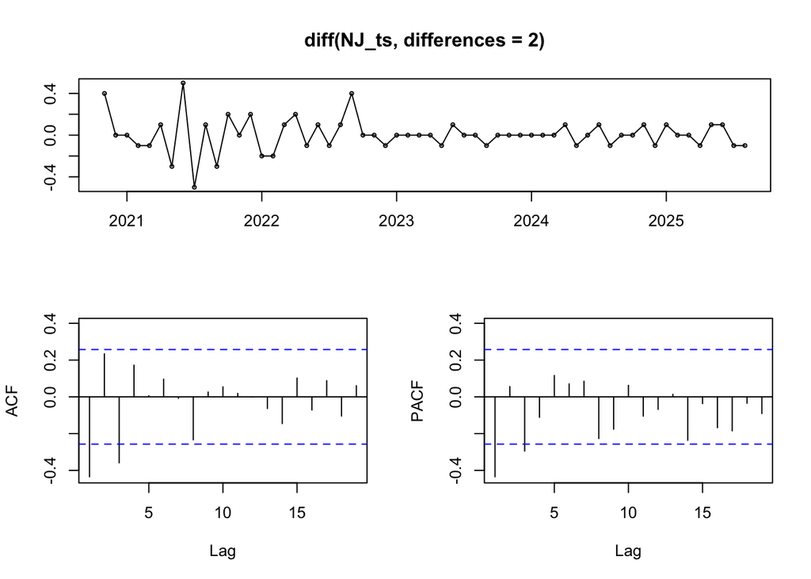

```r
# Second Difference
tsdisplay(diff(NJ_ts, differences = 2))
```

# After second differencing, the series becomes more stationary. The ACF shows significant negative spikes at Lags 1 and 3, suggesting q might be 0, 1, 2, or 3. The PACF also shows significant spikes at Lags 1 and 3, suggesting p might be 0, 1, 2, or 3.

# Check the plot

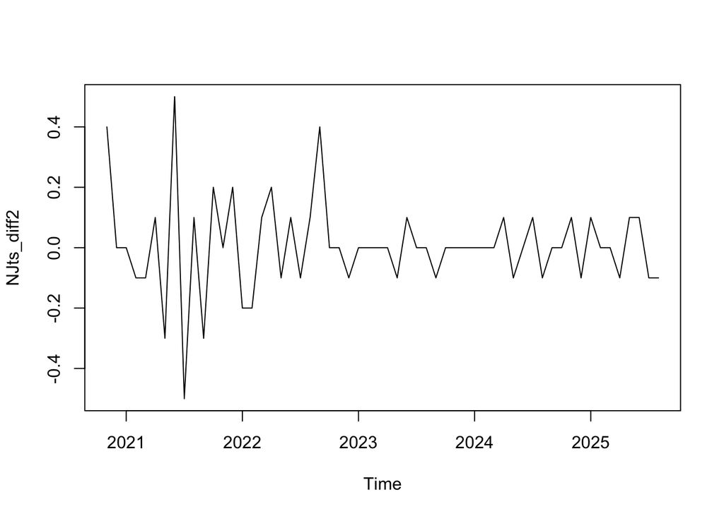

```r
NJts_diff2 = diff(NJ_ts, differences = 2)
plot(NJts_diff2)
```

# After second-order differencing, the series fluctuates around zero without a clear trend, suggesting that the data has become more stationary. However, the fluctuations are larger before 2023 and smaller afterward, indicating that the variance may not be constant over time.

# Auto fit for ARIMA

```r
auto_fit <- auto.arima(NJ_ts, trace=TRUE, stepwise = FALSE)
```

```
##
##  ARIMA(0,2,0)                               : -47.28671
##  ARIMA(0,2,0)(0,0,1)[12]                    : -45.13996
##  ARIMA(0,2,0)(1,0,0)[12]                    : -45.13996
##  ARIMA(0,2,0)(1,0,1)[12]                    : Inf
##  ARIMA(0,2,1)                               : -58.95617
##  ARIMA(0,2,1)(0,0,1)[12]                    : -57.59799
##  ARIMA(0,2,1)(1,0,0)[12]                    : -57.70033
##  ARIMA(0,2,1)(1,0,1)[12]                    : Inf
##  ARIMA(0,2,2)                               : -56.79755
##  ARIMA(0,2,2)(0,0,1)[12]                    : -55.35868
##  ARIMA(0,2,2)(1,0,0)[12]                    : -55.44578
##  ARIMA(0,2,2)(1,0,1)[12]                    : Inf
##  ARIMA(0,2,3)                               : -58.36957
##  ARIMA(0,2,3)(0,0,1)[12]                    : -56.26844
##  ARIMA(0,2,3)(1,0,0)[12]                    : -56.31659
##  ARIMA(0,2,3)(1,0,1)[12]                    : Inf
##  ARIMA(0,2,4)                               : -58.09005
##  ARIMA(0,2,4)(0,0,1)[12]                    : -55.6229
##  ARIMA(0,2,4)(1,0,0)[12]                    : -55.62435
##  ARIMA(0,2,5)                               : -56.99985
##  ARIMA(1,2,0)                               : -58.82424
##  ARIMA(1,2,0)(0,0,1)[12]                    : -56.91968
##  ARIMA(1,2,0)(1,0,0)[12]                    : -56.93681
##  ARIMA(1,2,0)(1,0,1)[12]                    : Inf
##  ARIMA(1,2,1)                               : -56.85986
##  ARIMA(1,2,1)(0,0,1)[12]                    : -55.41027
##  ARIMA(1,2,1)(1,0,0)[12]                    : -55.48612
##  ARIMA(1,2,1)(1,0,1)[12]                    : Inf
##  ARIMA(1,2,2)                               : -56.3115
##  ARIMA(1,2,2)(0,0,1)[12]                    : -54.52953
##  ARIMA(1,2,2)(1,0,0)[12]                    : -54.56907
##  ARIMA(1,2,2)(1,0,1)[12]                    : Inf
##  ARIMA(1,2,3)                               : -57.99274
##  ARIMA(1,2,3)(0,0,1)[12]                    : -55.57579
##  ARIMA(1,2,3)(1,0,0)[12]                    : -55.58761
##  ARIMA(1,2,4)                               : -57.60447
##  ARIMA(2,2,0)                               : -56.63068
##  ARIMA(2,2,0)(0,0,1)[12]                    : -54.61222
##  ARIMA(2,2,0)(1,0,0)[12]                    : -54.62883
```

[output cut: 11 more lines]

```
##  ARIMA(3,2,0)(1,0,0)[12]                    : -58.02984
##  ARIMA(3,2,0)(1,0,1)[12]                    : Inf
##  ARIMA(3,2,1)                               : -58.59934
##  ARIMA(3,2,1)(0,0,1)[12]                    : -56.28557
##  ARIMA(3,2,1)(1,0,0)[12]                    : -56.31003
##  ARIMA(3,2,2)                               : Inf
##  ARIMA(4,2,0)                               : -59.28528
##  ARIMA(4,2,0)(0,0,1)[12]                    : -57.05911
##  ARIMA(4,2,0)(1,0,0)[12]                    : -57.08918
##  ARIMA(4,2,1)                               : -58.83683
##  ARIMA(5,2,0)                               : -57.87415
##
##
##
##  Best model: ARIMA(3,2,0)
```

```r
auto_fit
```

```
## Series: NJ_ts
## ARIMA(3,2,0)
##
## Coefficients:
##           ar1      ar2      ar3
##       -0.4582  -0.1373  -0.3342
## s.e.   0.1341   0.1481   0.1315
##
## sigma^2 = 0.01856:  log likelihood = 34.56
## AIC=-61.11   AICc=-60.36   BIC=-52.87
```

# The auto.arima() function selected ARIMA(3,2,0) as the best model, indicating three autoregressive terms, two times differencing, and no moving average terms. The model has an AIC of -61.11, AICc of -60.36, and BIC of -52.87. Further residual analysis is needed to evaluate the model’s adequacy.

# Forecast for Unemployment rate with ARIMA

```r
attributes(auto_fit)
```

```
## $names
##  [1] "coef"      "sigma2"    "var.coef"  "mask"      "loglik"    "aic"
##  [7] "arma"      "residuals" "call"      "series"    "code"      "n.cond"
## [13] "nobs"      "model"     "bic"       "aicc"      "x"         "fitted"
##
## $class
## [1] "fc_model"       "forecast_ARIMA" "ARIMA"          "Arima"
```

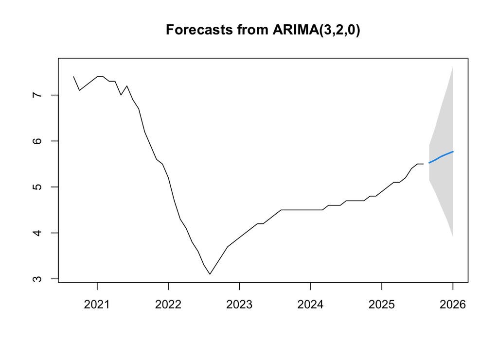

```r
plot(forecast(auto_fit,h=5,level=c(99.5)))
```

# The ARIMA(3,2,0) model forecasts a slight increase in NJ unemployment rate over the next five months. The widening 99.5% prediction interval indicates increasing uncertainty over longer forecast horizons. To sum up, The model suggests a gradual upward trend in unemployment.

# Summary of ARIMA model

```r
summary(auto_fit)
```

```
## Series: NJ_ts
## ARIMA(3,2,0)
##
## Coefficients:
##           ar1      ar2      ar3
##       -0.4582  -0.1373  -0.3342
## s.e.   0.1341   0.1481   0.1315
##
## sigma^2 = 0.01856:  log likelihood = 34.56
## AIC=-61.11   AICc=-60.36   BIC=-52.87
##
## Training set error measures:
##                       ME      RMSE        MAE       MPE     MAPE       MASE
## Training set 0.009061964 0.1304372 0.08938866 0.3061969 1.778762 0.07334454
##                      ACF1
## Training set -0.008575181
```

# Residual Analysis for ARIMA

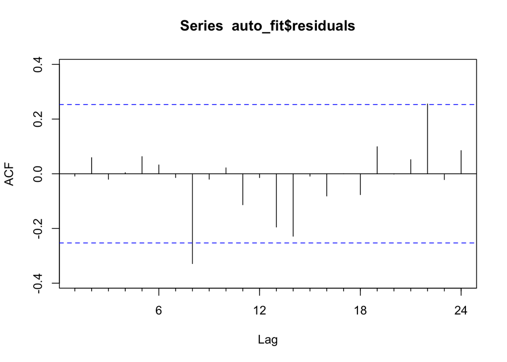

```r
Acf(auto_fit$residuals)
```

# Most residual autocorrelations fall within the 95% confidence intervals, suggesting that the ARIMA(3,2,0) model captures much of the time series structure. However, a significant negative spike at Lag 8 indicates some remaining autocorrelation.

# Box test for residual

```r
Box.test(residuals(auto_fit), lag=20, type="Ljung")
```

```
##
##  Box-Ljung test
##
## data:  residuals(auto_fit)
## X-squared = 18.588, df = 20, p-value = 0.5487
```

# The Ljung-Box test gives a p-value of 0.5487, which is greater than 0.05. Therefore, we fail to reject the null hypothesis that there is no autocorrelation within Lag range for residual. This supports the adequacy of the ARIMA(3,2,0) model.

# Plot the residual

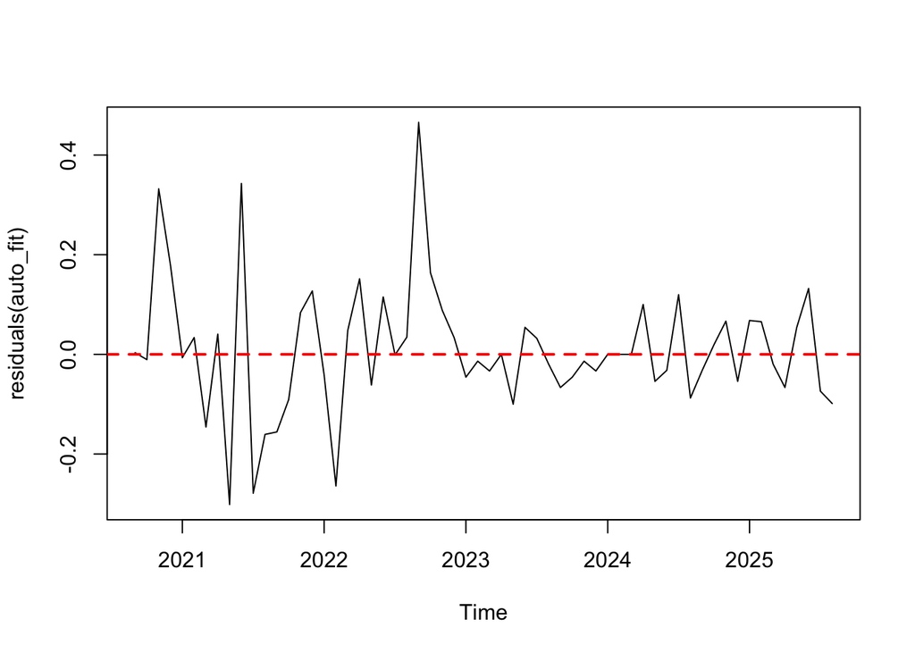

```r
plot.ts(residuals(auto_fit))
abline(h = 0, col = "red", lty = 2, lwd = 2)
```

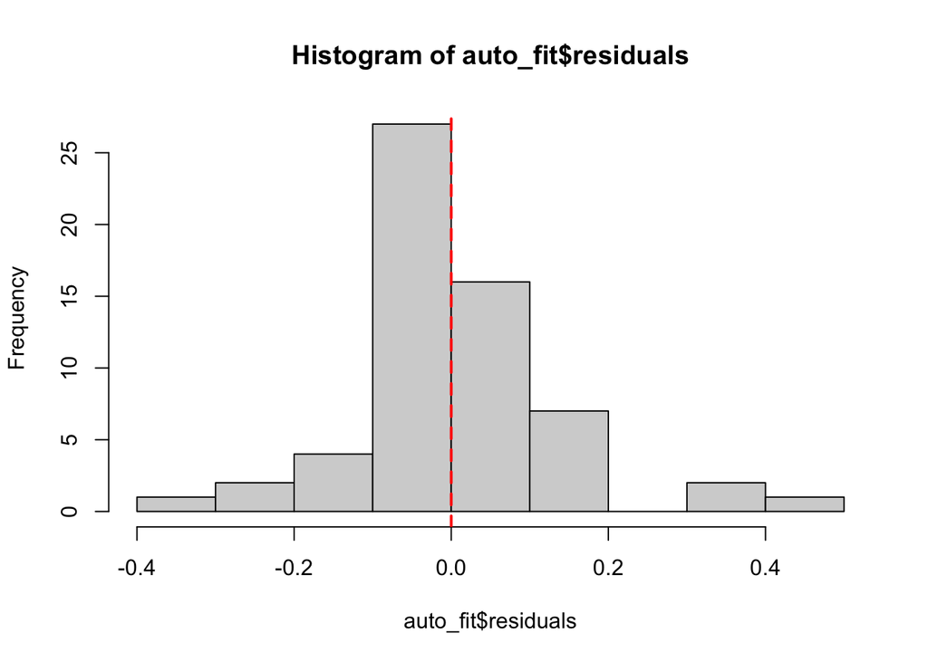

```r
hist(auto_fit$residuals)
abline(v = 0, col = "red", lty = 2, lwd = 2)
```

# According to the two graphs, the residuals are mostly concentrated around zero, suggesting that the model has little systematic bias. However, the distribution is not perfectly symmetric and contains a few extreme values, indicating some deviations from normality.

# Check if ARIMA model reasonable

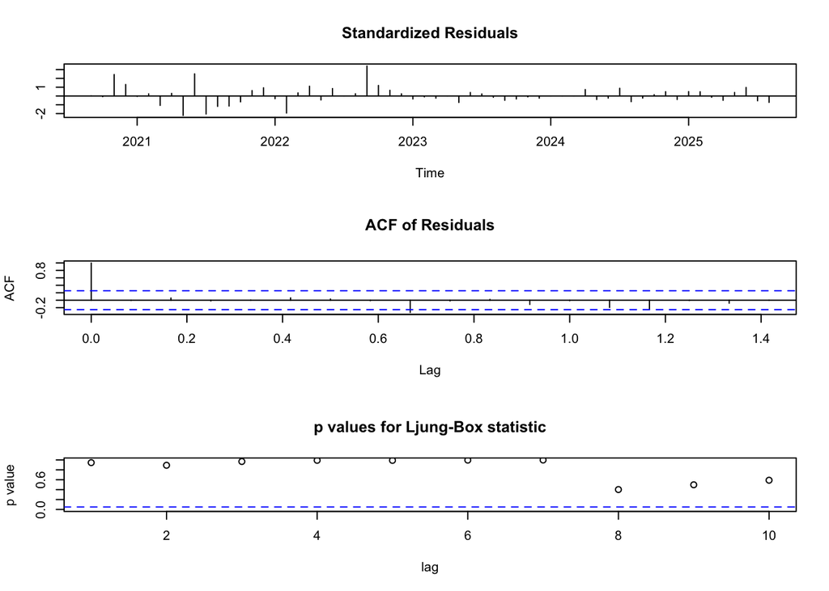

```r
tsdiag(auto_fit)
```

# The ARIMA(3,2,0) model appears reasonable, as the residuals are centered around zero and the Ljung-Box tests show no significant overall autocorrelation. However, there are some outliers and changes in residual variance remain.

# Check if Seasonal ARIMA needed

```r
nsdiffs(NJ_ts)
```

```
## [1] 0
```

# R suggest there is no need to do Seasonal Differencing for NJ unemployment rate.

# Let R decide if seasonal needed.

```r
# Seasonal ARIMA
fit_seasonal <- auto.arima(
  NJ_ts,
  seasonal = TRUE,
  trace = TRUE,
  stepwise = FALSE,
  approximation = FALSE
)
```

```
##
##  ARIMA(0,2,0)                               : -47.28671
##  ARIMA(0,2,0)(0,0,1)[12]                    : -45.13996
##  ARIMA(0,2,0)(1,0,0)[12]                    : -45.13996
##  ARIMA(0,2,0)(1,0,1)[12]                    : Inf
##  ARIMA(0,2,1)                               : -58.95617
##  ARIMA(0,2,1)(0,0,1)[12]                    : -57.59799
##  ARIMA(0,2,1)(1,0,0)[12]                    : -57.70033
##  ARIMA(0,2,1)(1,0,1)[12]                    : Inf
##  ARIMA(0,2,2)                               : -56.79755
##  ARIMA(0,2,2)(0,0,1)[12]                    : -55.35868
##  ARIMA(0,2,2)(1,0,0)[12]                    : -55.44578
##  ARIMA(0,2,2)(1,0,1)[12]                    : Inf
##  ARIMA(0,2,3)                               : -58.36957
##  ARIMA(0,2,3)(0,0,1)[12]                    : -56.26844
##  ARIMA(0,2,3)(1,0,0)[12]                    : -56.31659
##  ARIMA(0,2,3)(1,0,1)[12]                    : Inf
##  ARIMA(0,2,4)                               : -58.09005
##  ARIMA(0,2,4)(0,0,1)[12]                    : -55.6229
##  ARIMA(0,2,4)(1,0,0)[12]                    : -55.62435
##  ARIMA(0,2,5)                               : -56.99985
##  ARIMA(1,2,0)                               : -58.82424
##  ARIMA(1,2,0)(0,0,1)[12]                    : -56.91968
##  ARIMA(1,2,0)(1,0,0)[12]                    : -56.93681
##  ARIMA(1,2,0)(1,0,1)[12]                    : Inf
##  ARIMA(1,2,1)                               : -56.85986
##  ARIMA(1,2,1)(0,0,1)[12]                    : -55.41027
##  ARIMA(1,2,1)(1,0,0)[12]                    : -55.48612
##  ARIMA(1,2,1)(1,0,1)[12]                    : Inf
##  ARIMA(1,2,2)                               : -56.3115
##  ARIMA(1,2,2)(0,0,1)[12]                    : -54.52953
##  ARIMA(1,2,2)(1,0,0)[12]                    : -54.56907
##  ARIMA(1,2,2)(1,0,1)[12]                    : Inf
##  ARIMA(1,2,3)                               : -57.99274
##  ARIMA(1,2,3)(0,0,1)[12]                    : -55.57579
##  ARIMA(1,2,3)(1,0,0)[12]                    : -55.58761
##  ARIMA(1,2,4)                               : -57.60447
##  ARIMA(2,2,0)                               : -56.63068
##  ARIMA(2,2,0)(0,0,1)[12]                    : -54.61222
##  ARIMA(2,2,0)(1,0,0)[12]                    : -54.62883
```

[output cut: 11 more lines]

```
##  ARIMA(3,2,0)(1,0,0)[12]                    : -58.02984
##  ARIMA(3,2,0)(1,0,1)[12]                    : Inf
##  ARIMA(3,2,1)                               : -58.59934
##  ARIMA(3,2,1)(0,0,1)[12]                    : -56.28557
##  ARIMA(3,2,1)(1,0,0)[12]                    : -56.31003
##  ARIMA(3,2,2)                               : Inf
##  ARIMA(4,2,0)                               : -59.28528
##  ARIMA(4,2,0)(0,0,1)[12]                    : -57.05911
##  ARIMA(4,2,0)(1,0,0)[12]                    : -57.08918
##  ARIMA(4,2,1)                               : -58.83683
##  ARIMA(5,2,0)                               : -57.87415
##
##
##
##  Best model: ARIMA(3,2,0)
```

```r
fit_seasonal
```

```
## Series: NJ_ts
## ARIMA(3,2,0)
##
## Coefficients:
##           ar1      ar2      ar3
##       -0.4582  -0.1373  -0.3342
## s.e.   0.1341   0.1481   0.1315
##
## sigma^2 = 0.01856:  log likelihood = 34.56
## AIC=-61.11   AICc=-60.36   BIC=-52.87
```

# Same result as previous even we set up seasonal as TRUE, which means R can check if Seasonal ARIMA will perform better than ARIMA for NJ unemployment rate. The ndiffs() result suggests two regular differences (d = 2), while nsdiffs() indicates that seasonal differencing is unnecessary (D = 0). The auto.arima() function selected ARIMA(3,2,0), suggesting that additional seasonal terms may not be needed. Therefore, the non-seasonal ARIMA model is preferred for this dataset.

# Conclusion: Based on the analysis, ARIMA(3,2,0) was selected as the best model for forecasting NJ unemployment rate. The ndiffs() result suggested two regular differences, while nsdiffs() indicated that seasonal differencing was unnecessary. The model achieved an AICc of -60.36, and the residual analysis showed no significant overall autocorrelation based on the Ljung-Box test. The five-month forecast predicts a gradual increase in the unemployment rate.ARIMA(3,2,0) is a reasonable model for short-term unemployment forecasting.